# Life History Attributes Influencing Metabolic Variation in an Estuarine Fish

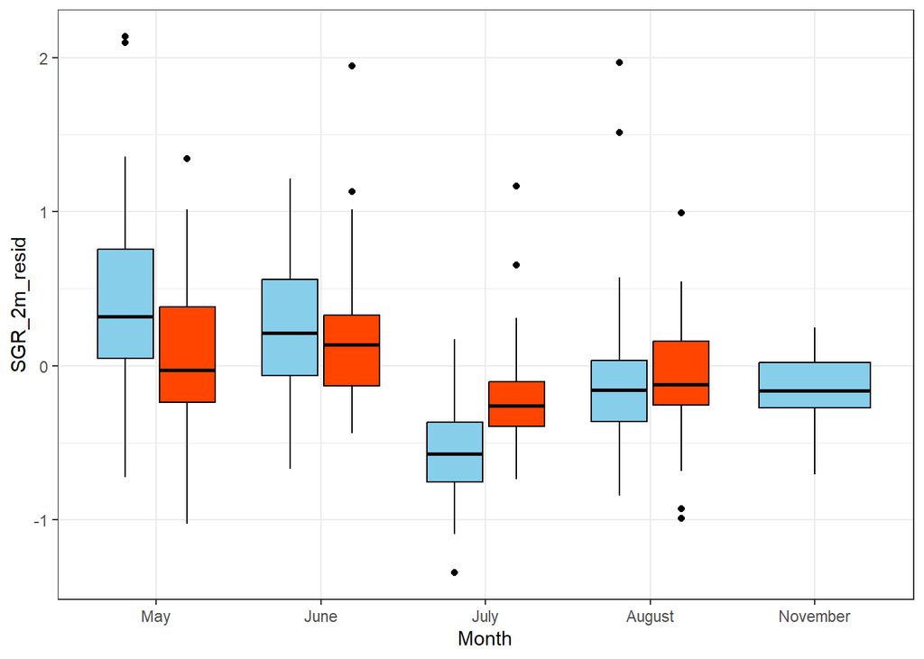

Now we move on to look at the relationship between SGR and mass-standardized SMR.

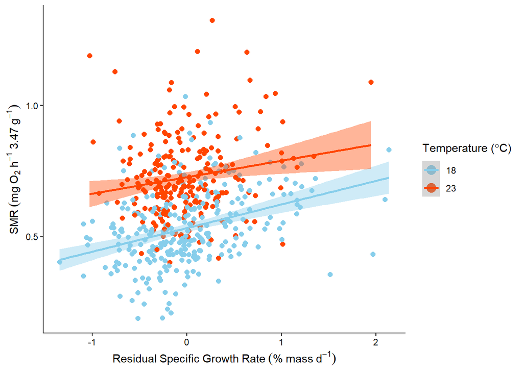

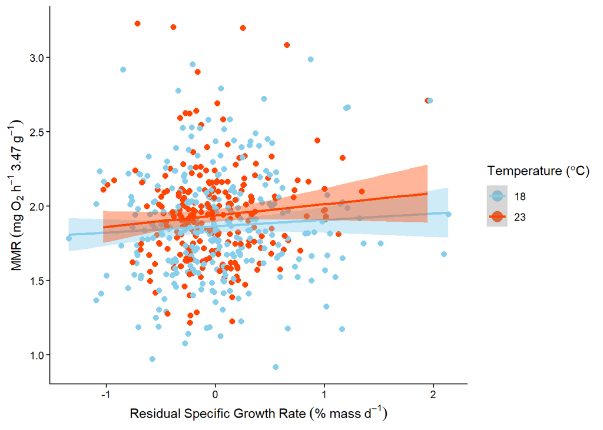

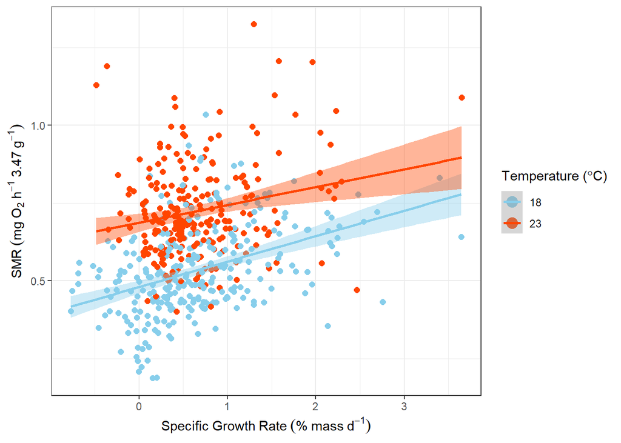

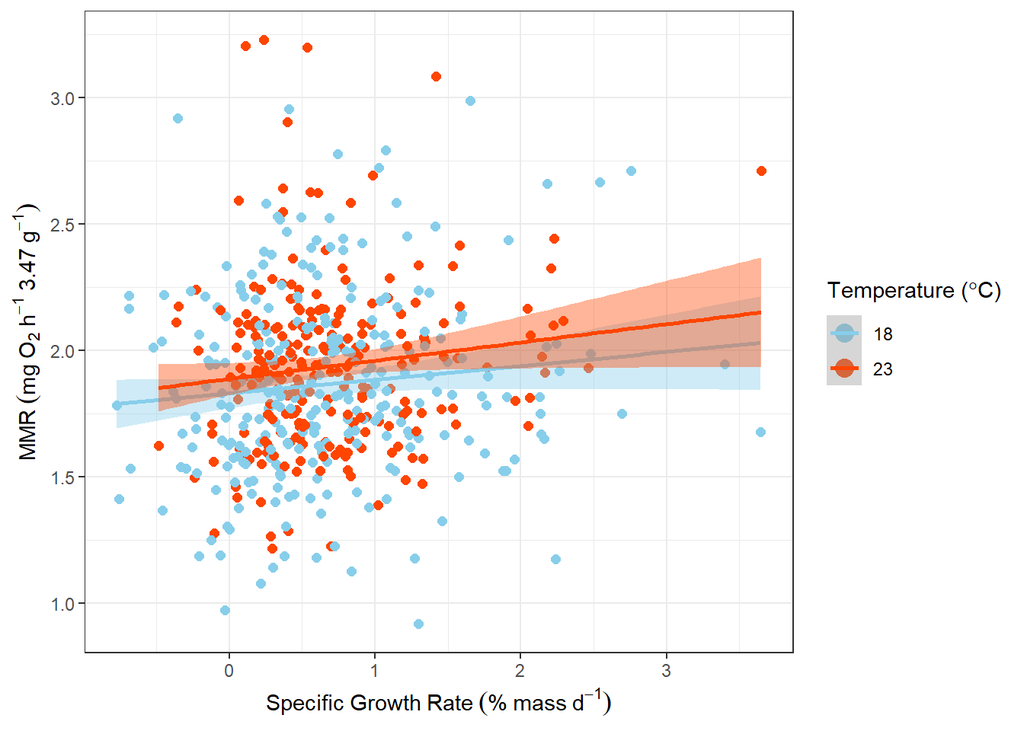

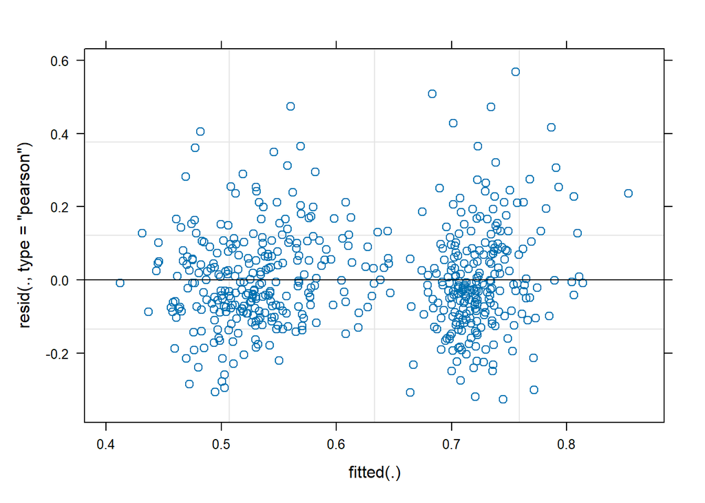

[figure not shown]

```
## Linear mixed model fit by REML. t-tests use Satterthwaite's method [
## lmerModLmerTest]
## Formula: SMR_mass ~ SGR_2m_resid * factor(Temp) + (1 | ID)
##    Data: data_sgr
##
## REML criterion at convergence: -533.8
##
## Scaled residuals:
##     Min      1Q  Median      3Q     Max
## -2.3517 -0.6281 -0.1122  0.5618  4.0920
##
## Random effects:
##  Groups   Name        Variance  Std.Dev.
##  ID       (Intercept) 0.0008468 0.0291
##  Residual             0.0193303 0.1390
## Number of obs: 522, groups:  ID, 166
##
## Fixed effects:
##                               Estimate Std. Error         df t value Pr(>|t|)
## (Intercept)                   0.531009   0.008918 147.015197  59.541  < 2e-16
## SGR_2m_resid                  0.089116   0.015001 437.921998   5.941 5.79e-09
## factor(Temp)23                0.195239   0.013157 122.132769  14.839  < 2e-16
## SGR_2m_resid:factor(Temp)23  -0.028213   0.026245 464.593698  -1.075    0.283
##
## (Intercept)                 ***
## SGR_2m_resid                ***
## factor(Temp)23              ***
## SGR_2m_resid:factor(Temp)23
## ---
## Signif. codes:  0 '***' 0.001 '**' 0.01 '*' 0.05 '.' 0.1 ' ' 1
##
## Correlation of Fixed Effects:
##             (Intr) SGR_2m_ f(T)23
## SGR_2m_resd -0.023
## fctr(Tmp)23 -0.678  0.015
## SGR_2_:(T)2  0.013 -0.572   0.014
```

```
## Linear mixed model fit by REML. t-tests use Satterthwaite's method [
## lmerModLmerTest]
## Formula: SMR_mass ~ SGR_2m_resid + (1 | ID)
##    Data: data_sgr[which(data_sgr$Temp == 18), ]
##
## REML criterion at convergence: -320.8
##
## Scaled residuals:
##     Min      1Q  Median      3Q     Max
## -2.4033 -0.6369 -0.1138  0.5927  3.7837
##
## Random effects:
##  Groups   Name        Variance Std.Dev.
##  ID       (Intercept) 0.00000  0.0000
##  Residual             0.01773  0.1332
## Number of obs: 279, groups:  ID, 105
##
## Fixed effects:
##               Estimate Std. Error        df t value Pr(>|t|)
## (Intercept)  5.321e-01  7.975e-03 2.770e+02  66.722  < 2e-16 ***
## SGR_2m_resid 9.010e-02  1.426e-02 2.770e+02   6.319 1.05e-09 ***
## ---
## Signif. codes:  0 '***' 0.001 '**' 0.01 '*' 0.05 '.' 0.1 ' ' 1
##
## Correlation of Fixed Effects:
##             (Intr)
## SGR_2m_resd -0.026
## optimizer (nloptwrap) convergence code: 0 (OK)
## boundary (singular) fit: see help('isSingular')
```

```
## $model
## [1] 0.1259983
##
## $fixed
## [1] 0.1259983
##
## $random
## [1] 0
```

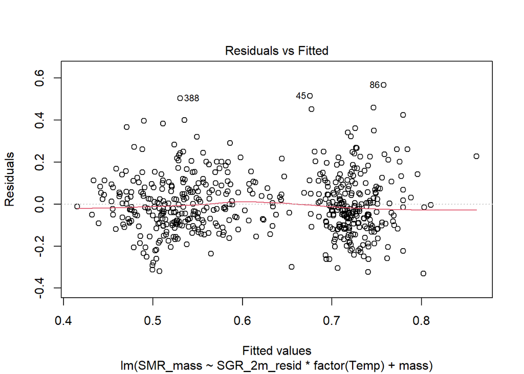

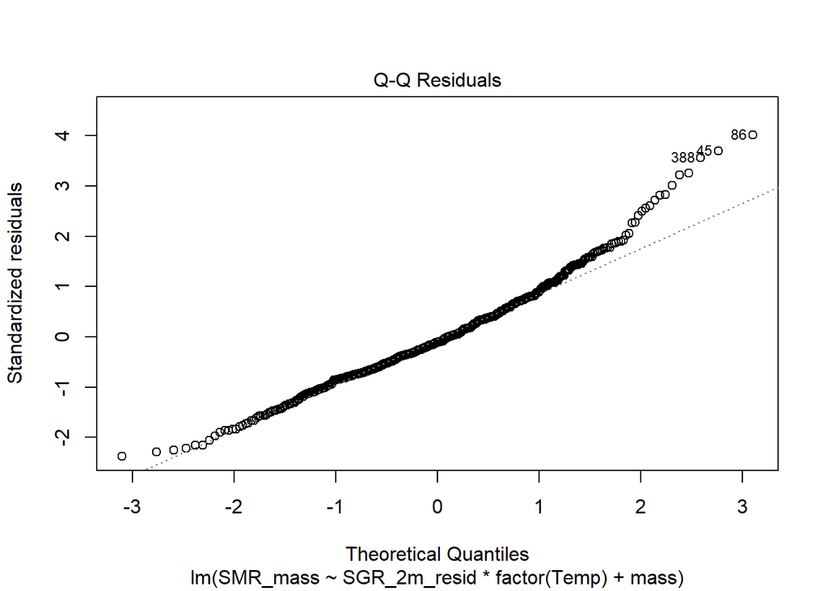

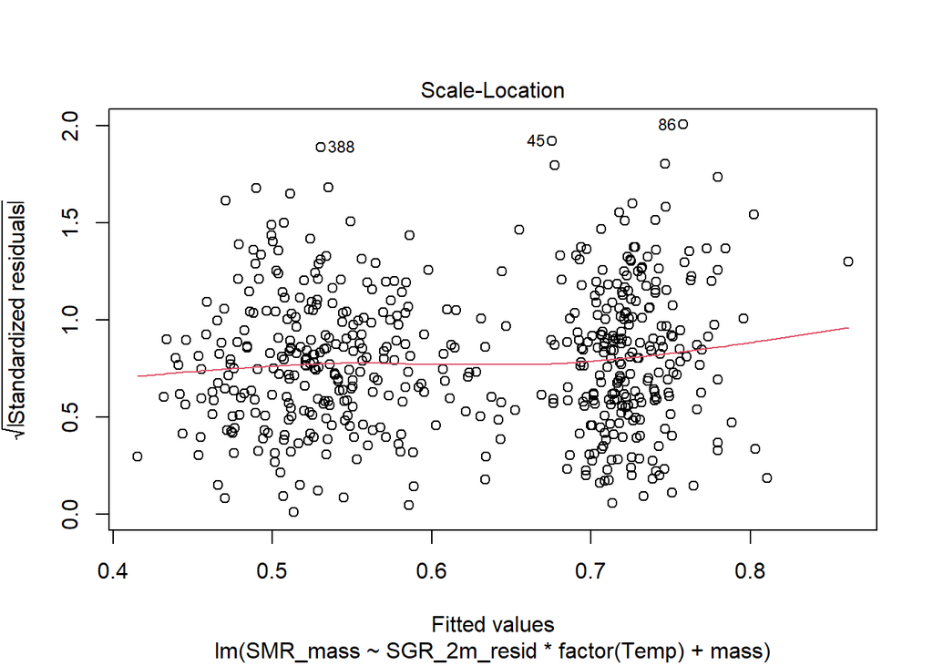

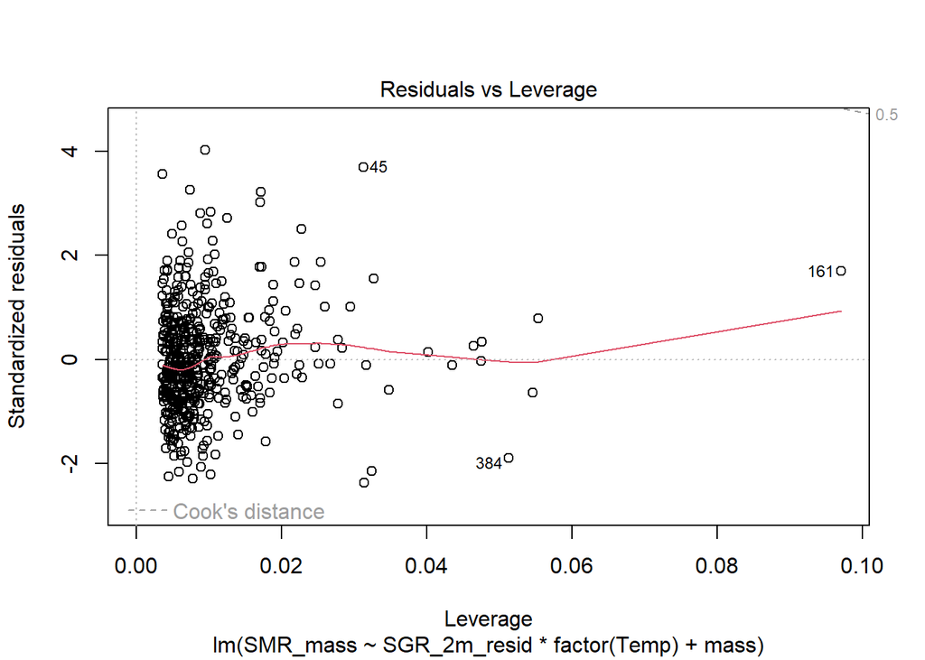

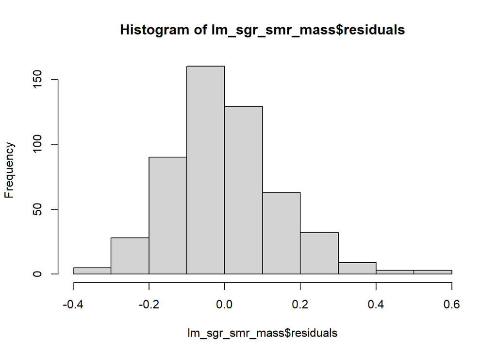

```
##
## Call:
## lm(formula = SMR_mass ~ SGR_2m_resid * factor(Temp) + mass, data = data_sgr)
##
## Residuals:
##      Min       1Q   Median       3Q      Max
## -0.33144 -0.09310 -0.01496  0.07894  0.56713
##
## Coefficients:
##                              Estimate Std. Error t value Pr(>|t|)
## (Intercept)                  0.557756   0.017012  32.786  < 2e-16 ***
## SGR_2m_resid                 0.089233   0.015183   5.877 7.49e-09 ***
## factor(Temp)23               0.188667   0.012842  14.691  < 2e-16 ***
## mass                        -0.007691   0.004420  -1.740   0.0825 .
## SGR_2m_resid:factor(Temp)23 -0.024965   0.026497  -0.942   0.3465
## ---
## Signif. codes:  0 '***' 0.001 '**' 0.01 '*' 0.05 '.' 0.1 ' ' 1
##
## Residual standard error: 0.1417 on 517 degrees of freedom
## Multiple R-squared:  0.3551, Adjusted R-squared:  0.3501
## F-statistic: 71.16 on 4 and 517 DF,  p-value: < 2.2e-16
```

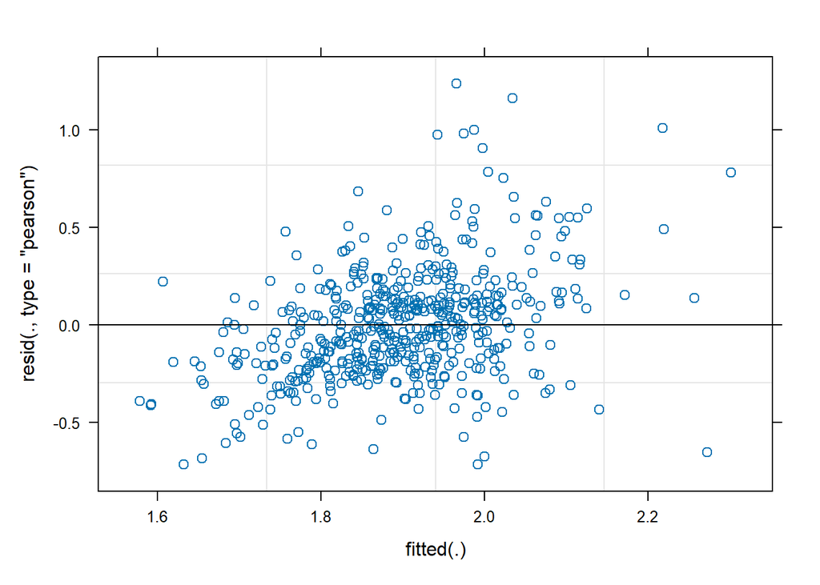

[figure not shown]

```
## Linear mixed model fit by REML. t-tests use Satterthwaite's method [
## lmerModLmerTest]
## Formula: MMR_mass ~ SGR_2m_resid * factor(Temp) + (1 | ID)
##    Data: data_sgr
##
## REML criterion at convergence: 368.7
##
## Scaled residuals:
##     Min      1Q  Median      3Q     Max
## -2.3137 -0.6212 -0.0618  0.4661  3.9984
##
## Random effects:
##  Groups   Name        Variance Std.Dev.
##  ID       (Intercept) 0.02451  0.1565
##  Residual             0.09602  0.3099
## Number of obs: 522, groups:  ID, 166
##
## Fixed effects:
##                              Estimate Std. Error        df t value Pr(>|t|)
## (Intercept)                   1.84670    0.02500 149.96674  73.877   <2e-16 ***
## SGR_2m_resid                  0.03077    0.03416 407.42331   0.901   0.3683
## factor(Temp)23                0.08929    0.03772 122.65263   2.367   0.0195 *
## SGR_2m_resid:factor(Temp)23   0.03036    0.06012 417.39841   0.505   0.6138
## ---
## Signif. codes:  0 '***' 0.001 '**' 0.01 '*' 0.05 '.' 0.1 ' ' 1
##
## Correlation of Fixed Effects:
##             (Intr) SGR_2m_ f(T)23
## SGR_2m_resd -0.012
## fctr(Tmp)23 -0.663  0.008
## SGR_2_:(T)2  0.007 -0.568   0.014
```

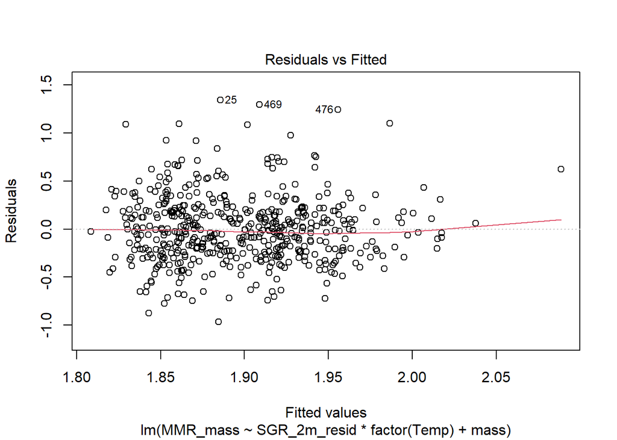

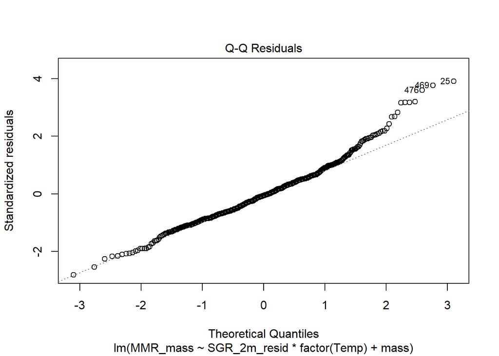

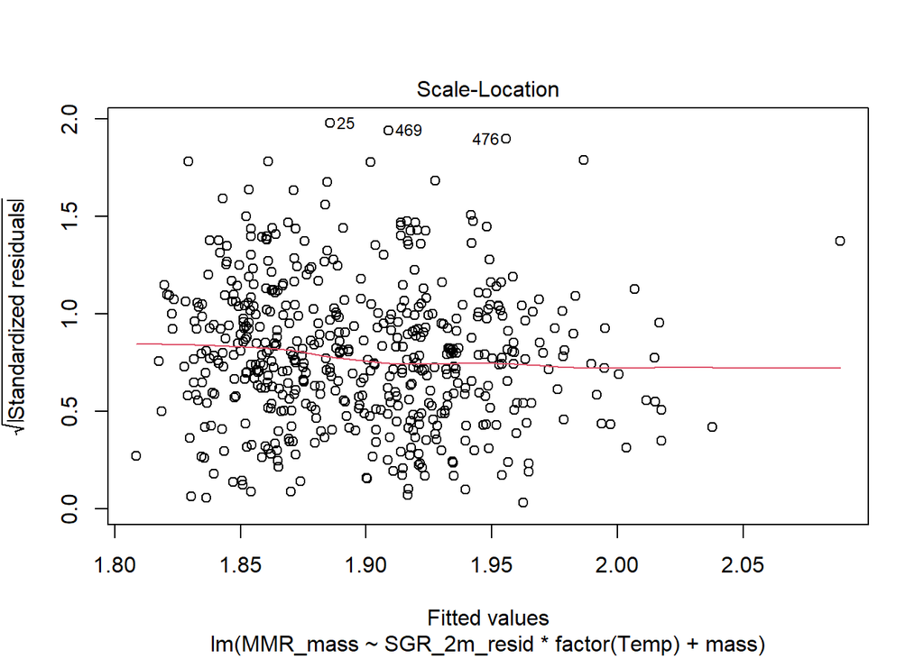

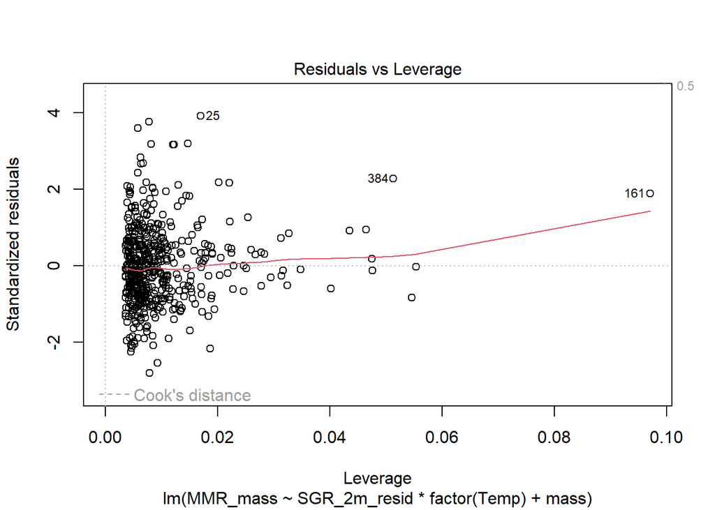

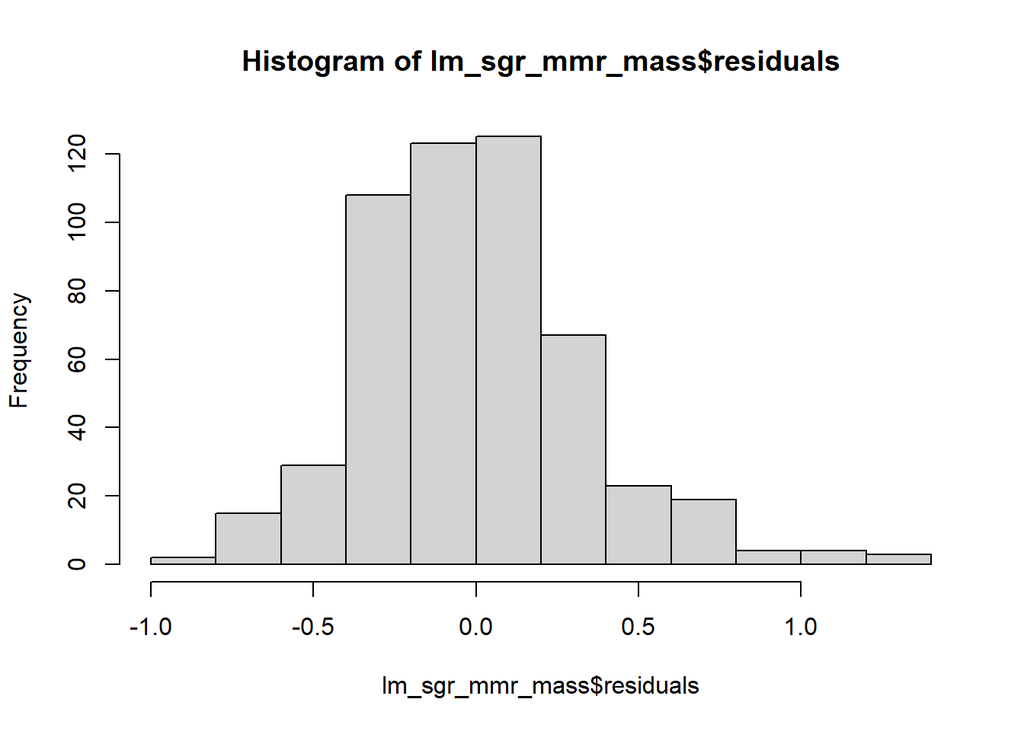

```
##
## Call:
## lm(formula = MMR_mass ~ SGR_2m_resid * factor(Temp) + mass, data = data_sgr)
##
## Residuals:
##      Min       1Q   Median       3Q      Max
## -0.96694 -0.22719 -0.02026  0.18207  1.34087
##
## Coefficients:
##                              Estimate Std. Error t value Pr(>|t|)
## (Intercept)                  1.873897   0.041484  45.171   <2e-16 ***
## SGR_2m_resid                 0.042185   0.037024   1.139   0.2551
## factor(Temp)23               0.070069   0.031316   2.237   0.0257 *
## mass                        -0.002976   0.010779  -0.276   0.7825
## SGR_2m_resid:factor(Temp)23  0.034099   0.064613   0.528   0.5979
## ---
## Signif. codes:  0 '***' 0.001 '**' 0.01 '*' 0.05 '.' 0.1 ' ' 1
##
## Residual standard error: 0.3456 on 517 degrees of freedom
## Multiple R-squared:  0.01679,    Adjusted R-squared:  0.009178
## F-statistic: 2.207 on 4 and 517 DF,  p-value: 0.06716
```

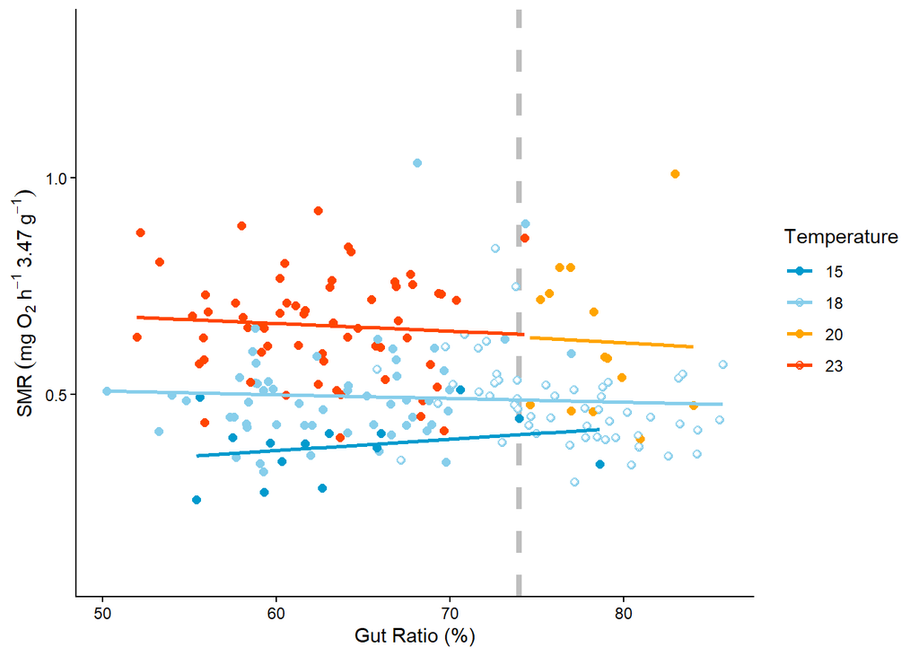

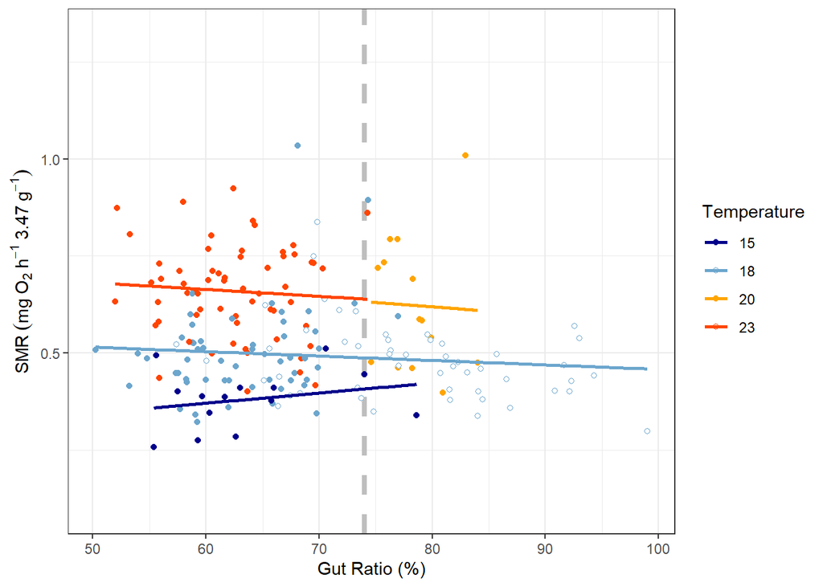

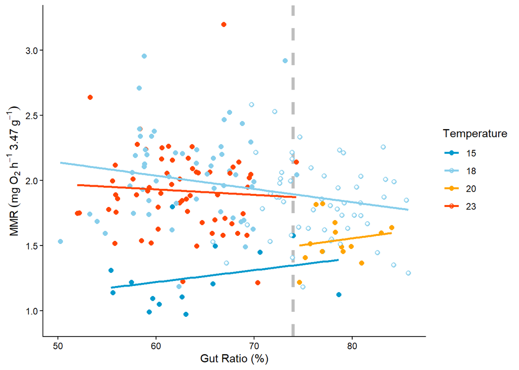

```r
# plot gut ratio vs. mass-standardized MMR, indicate extrapolated values:
fig6 <- ggplot() +
  geom_vline(xintercept = 74, color = "grey", linetype = "dashed", linewidth = 1.5) +
  geom_point(data = data, aes(x = Ratio, y = MMR_mass, color = factor(Temp)), size = 2) +
  geom_point(data = data[which(data$Month == "July"),], aes(x = Ratio, y = MMR_mass, color = factor(Temp)), shape = 21, fill = "white")+
  geom_smooth(data = data, aes(x = Ratio, y = MMR_mass, color = factor(Temp)), method = "lm", se = F) +
  scale_color_manual(values =c("deepskyblue3", "skyblue", "orange", "orangered"),
    guide = guide_legend()) +
  labs(x = "Gut Ratio (%)", y = expression(MMR~(mg~O[2]~h^-1~3.47~g^-1)), color = "Temperature") +
  theme_classic()

fig6
```

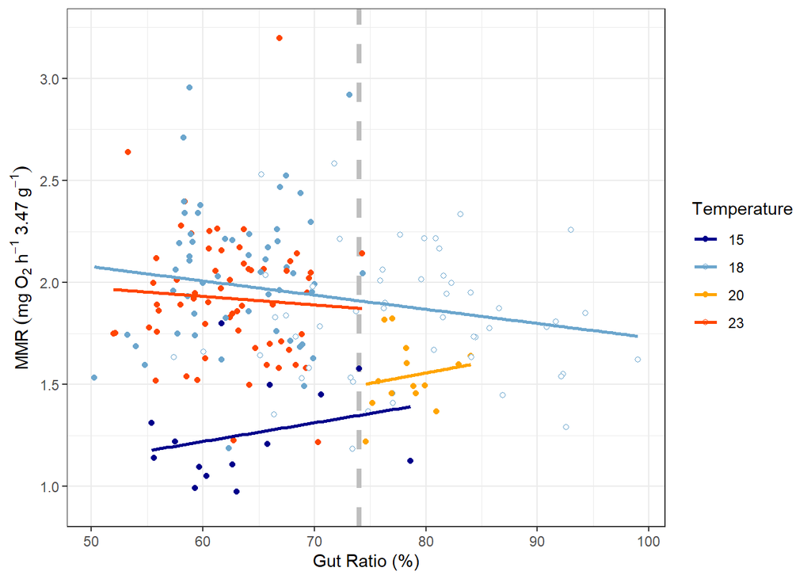

```r
# gut ratio vs. mass-standardized MMR but using linearly extrapolated gut ratio values:
ggplot() +
  geom_vline(xintercept = 74, color = "grey", linetype = "dashed", size = 1.5) +
  geom_point(data = data, aes(x = Ratio_linear, y = MMR_mass, color = factor(Temp))) +
  geom_point(data = data[which(data$Month == "July"),], aes(x = Ratio_linear, y = MMR_mass, color = factor(Temp)), shape = 21, fill = "white") +
  geom_smooth(data = data, aes(x = Ratio_linear, y = MMR_mass, color = factor(Temp)), method = "lm", se = F) +
  theme_bw() +
  scale_color_manual(values =c("darkblue", "skyblue3", "orange", "orangered")) +
  labs(x = "Gut Ratio (%)", y = expression(MMR~(mg~O[2]~h^-1~3.47~g^-1)), color = "Temperature")
```

Gut ratio really does not seem to have any correlation with mass-standardized SMR (any correlation seen between gut ratio and SMR could be explained by mass). Note that this figure uses the previously extrapolated values (above). For MMR, the case is a bit more complicated.

One way to explore this from a different perspective is to treat maturation as a binary state rather than a continuous variable. I will add a new column to data giving maturation status, and look for temperature-specific differences in SMR or MMR between the two states. Note that only 18C has a meaningful spread of data above and below the 0.74 threshold.

```r
data_matstat <- data %>%
 mutate(matstat = case_when(
    Ratio >= 74 ~ "Mature",
    Ratio < 74 ~ "Immature",
    is.na(Ratio) ~ NA,
    .default = "cusp")
  )
```

We could then run a linear regression test between metabolism and gut ratio at 18:

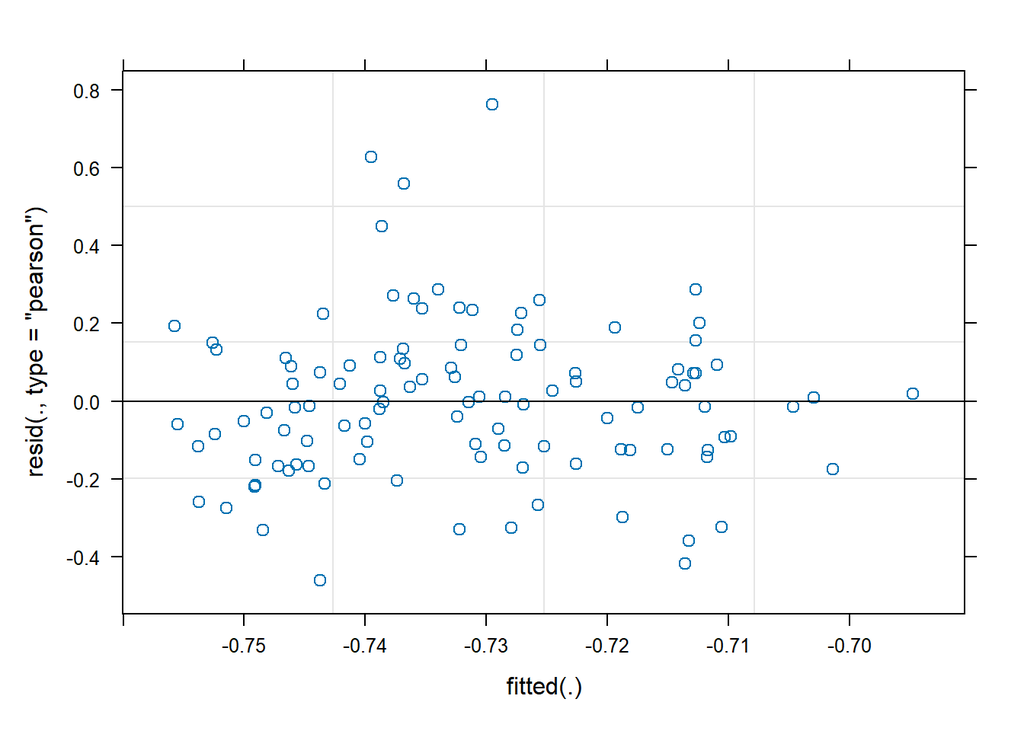

```r
data_matstat_18 <- data_matstat[which(data_matstat$Temp == 18 & !is.na(data_matstat$matstat)),]

lmod_SMR <- lmer(log(SMR_mass) ~ log(Ratio) + (1 | ID), data = data_matstat_18)
plot(lmod_SMR)
```

```r
summary(lmod_SMR)
```

```
## Linear mixed model fit by REML. t-tests use Satterthwaite's method [
## lmerModLmerTest]
## Formula: log(SMR_mass) ~ log(Ratio) + (1 | ID)
##    Data: data_matstat_18
##
## REML criterion at convergence: -31.1
##
## Scaled residuals:
##     Min      1Q  Median      3Q     Max
## -2.2606 -0.6143 -0.0439  0.5290  3.7382
##
## Random effects:
##  Groups   Name        Variance Std.Dev.
##  ID       (Intercept) 0.00000  0.0000
##  Residual             0.04172  0.2043
## Number of obs: 109, groups:  ID, 55
##
## Fixed effects:
##             Estimate Std. Error       df t value Pr(>|t|)
## (Intercept)  -0.2473     0.6734 107.0000  -0.367    0.714
## log(Ratio)   -0.1142     0.1588 107.0000  -0.719    0.473
##
## Correlation of Fixed Effects:
##            (Intr)
## log(Ratio) -1.000
## optimizer (nloptwrap) convergence code: 0 (OK)
## boundary (singular) fit: see help('isSingular')
```

```r
anova(lmod_SMR)
```

```
## Type III Analysis of Variance Table with Satterthwaite's method
##              Sum Sq  Mean Sq NumDF DenDF F value Pr(>F)
## log(Ratio) 0.021597 0.021597     1   107  0.5177 0.4734
```

```r
emm_SMR <- emtrends(lmod_SMR, ~1, var = "log(Ratio)")
emm_SMR
```

```
##  1       log(Ratio).trend    SE   df lower.CL upper.CL
##  overall           -0.114 0.161 97.4   -0.435    0.206
##
## Degrees-of-freedom method: kenward-roger
## Confidence level used: 0.95
```

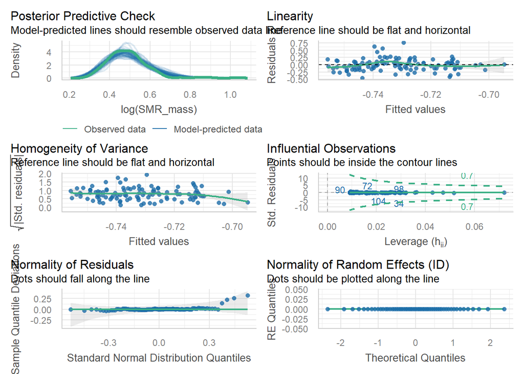

```r
performance::check_model(lmod_SMR, ask = F)
```

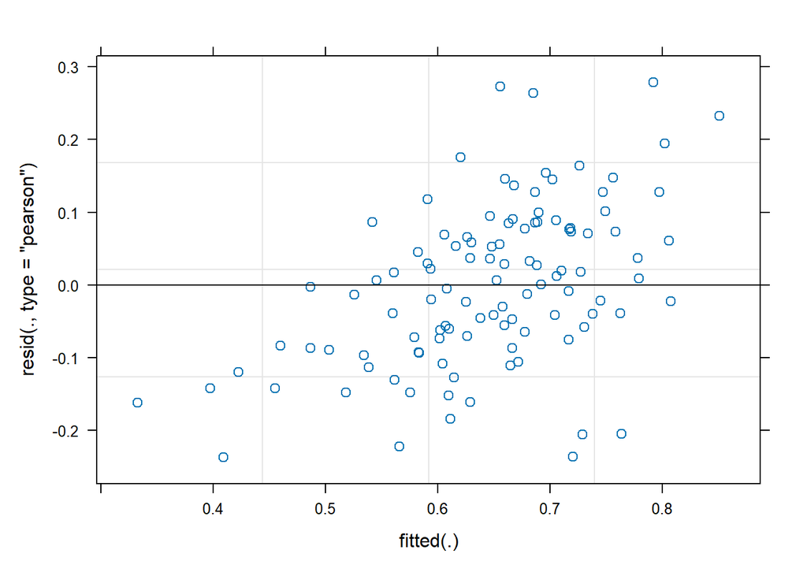

```r
lmod_MMR <- lmer(log(MMR_mass) ~ log(Ratio) + (1 | ID), data = data_matstat_18)
plot(lmod_MMR)
```

```r
summary(lmod_MMR)
```

```
## Linear mixed model fit by REML. t-tests use Satterthwaite's method [
## lmerModLmerTest]
## Formula: log(MMR_mass) ~ log(Ratio) + (1 | ID)
##    Data: data_matstat_18
##
## REML criterion at convergence: -76.4
##
## Scaled residuals:
##      Min       1Q   Median       3Q      Max
## -1.78636 -0.56569  0.00262  0.57678  2.10157
##
## Random effects:
##  Groups   Name        Variance Std.Dev.
##  ID       (Intercept) 0.01242  0.1115
##  Residual             0.01761  0.1327
## Number of obs: 109, groups:  ID, 55
##
## Fixed effects:
##             Estimate Std. Error      df t value Pr(>|t|)
## (Intercept)   2.4042     0.4898 75.9605   4.908 5.12e-06 ***
## log(Ratio)   -0.4148     0.1155 75.8185  -3.592  0.00058 ***
## ---
## Signif. codes:  0 '***' 0.001 '**' 0.01 '*' 0.05 '.' 0.1 ' ' 1
##
## Correlation of Fixed Effects:
##            (Intr)
## log(Ratio) -0.999
```

```r
anova(lmod_MMR)
```

```
## Type III Analysis of Variance Table with Satterthwaite's method
##             Sum Sq Mean Sq NumDF  DenDF F value    Pr(>F)
## log(Ratio) 0.22728 0.22728     1 75.818  12.903 0.0005802 ***
## ---
## Signif. codes:  0 '***' 0.001 '**' 0.01 '*' 0.05 '.' 0.1 ' ' 1
```

```r
emm_MMR <- emtrends(lmod_MMR, ~1, var = "log(Ratio)")
emm_MMR
```

```
##  1       log(Ratio).trend    SE   df lower.CL upper.CL
##  overall           -0.415 0.117 75.8   -0.647   -0.182
##
## Degrees-of-freedom method: kenward-roger
## Confidence level used: 0.95
```

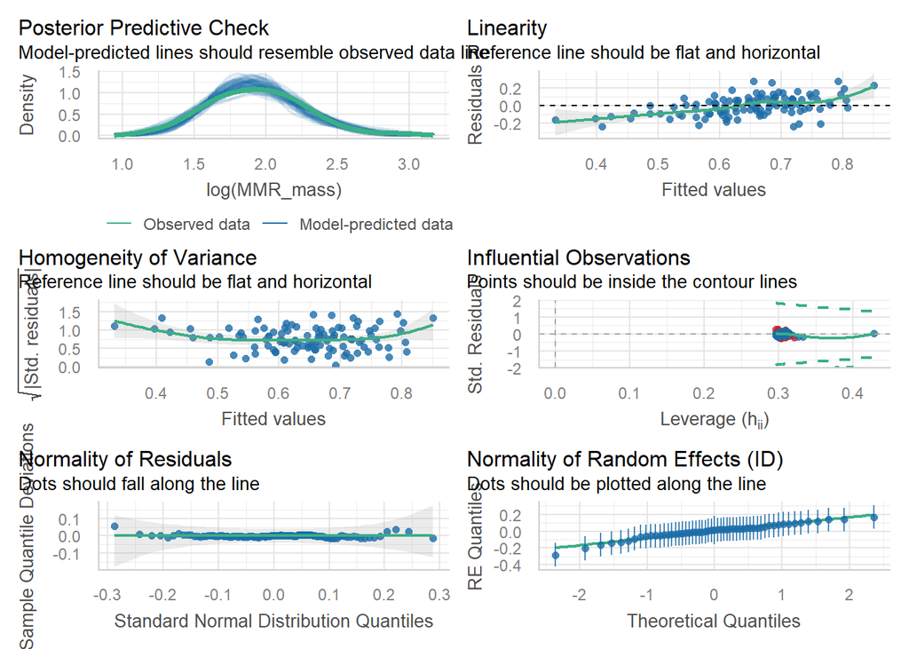

```r
performance::check_model(lmod_MMR, ask = F)
```

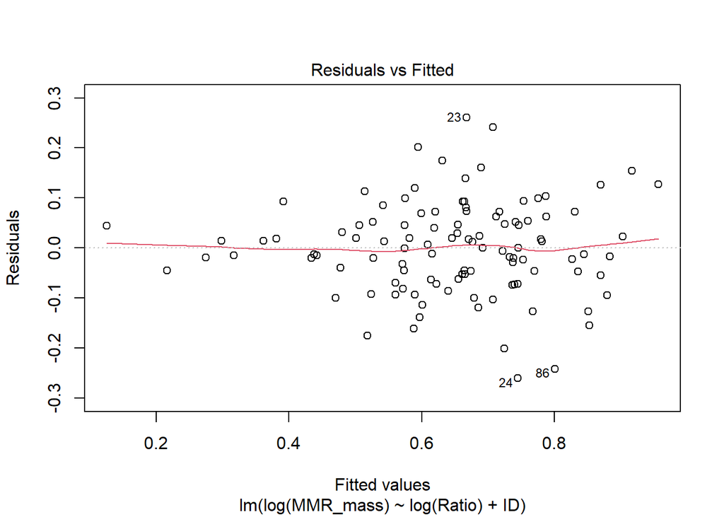

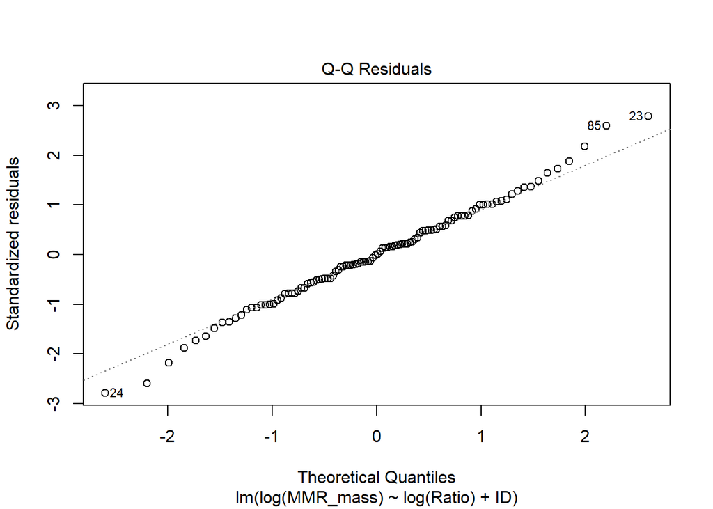

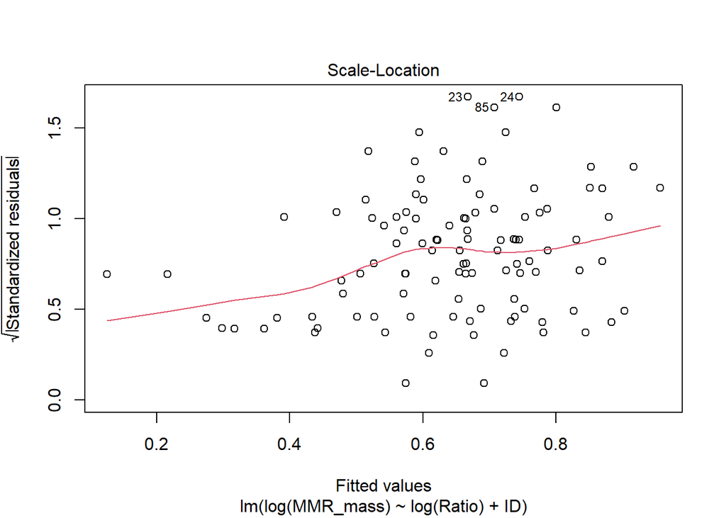

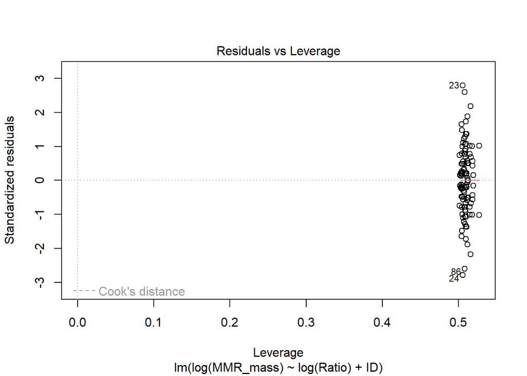

```r
#try again without random effects term (simple linear model) to verify trend is the same, because we saw a positive linear relationship in the residuals vs. predicted vals plot:

#MMR vs. gut ratio as a simple linear model and with ID as a fixed effect
lmod_MMR1 <- lm(log(MMR_mass) ~ log(Ratio) + ID, data = data_matstat_18)
plot(lmod_MMR1)
```

```r
summary(lmod_MMR1)
```

```
##
## Call:
## lm(formula = log(MMR_mass) ~ log(Ratio) + ID, data = data_matstat_18)
##
## Residuals:
##      Min       1Q   Median       3Q      Max
## -0.26059 -0.05422  0.00000  0.05422  0.26059
##
## Coefficients:
##             Estimate Std. Error t value Pr(>|t|)
## (Intercept)  2.37917    0.52831   4.503 3.71e-05 ***
## log(Ratio)  -0.49447    0.12799  -3.863 0.000307 ***
## IDB1_10      0.34273    0.13500   2.539 0.014101 *
## IDB1_11      0.45669    0.13568   3.366 0.001425 **
## IDB1_12      0.38280    0.13614   2.812 0.006891 **
## IDB1_13      0.27376    0.13649   2.006 0.050010 .
## IDB1_14      0.27748    0.13652   2.033 0.047126 *
## IDB1_15      0.28727    0.13628   2.108 0.039782 *
## IDB1_16      0.09647    0.13760   0.701 0.486306
## IDB1_17     -0.11901    0.13443  -0.885 0.379997
## IDB1_18      0.25237    0.13421   1.880 0.065545 .
## IDB1_2       0.34220    0.13466   2.541 0.014007 *
## IDB1_21      0.40361    0.13397   3.013 0.003964 **
## IDB1_22      0.40304    0.13413   3.005 0.004052 **
## IDB1_23      0.50717    0.13375   3.792 0.000385 ***
## IDB1_24      0.31923    0.13583   2.350 0.022519 *
## IDB1_25      0.26689    0.13380   1.995 0.051235 .
## IDB1_29      0.30422    0.13438   2.264 0.027705 *
## IDB1_31      0.66041    0.13811   4.782 1.42e-05 ***
## IDB1_34      0.41490    0.13615   3.047 0.003596 **
## IDB1_38      0.39352    0.13399   2.937 0.004895 **
## IDB1_39      0.40649    0.13344   3.046 0.003607 **
## IDB1_4       0.39787    0.13655   2.914 0.005218 **
## IDB1_41      0.56344    0.13646   4.129 0.000130 ***
## IDB1_42      0.36751    0.13359   2.751 0.008110 **
## IDB1_43      0.29768    0.13423   2.218 0.030885 *
## IDB1_44      0.21384    0.13620   1.570 0.122372
## IDB1_45      0.40318    0.13586   2.968 0.004497 **
## IDB1_46      0.32133    0.13352   2.407 0.019619 *
## IDB1_47      0.59181    0.13368   4.427 4.80e-05 ***
```

[output cut: 17 more lines]

```
## IDB1_73      0.27917    0.13368   2.088 0.041588 *
## IDB1_74      0.12932    0.13283   0.974 0.334689
## IDB1_75      0.47332    0.13382   3.537 0.000851 ***
## IDB1_76      0.42936    0.13434   3.196 0.002349 **
## IDB1_77      0.31767    0.13302   2.388 0.020524 *
## IDB1_78      0.38122    0.16267   2.344 0.022882 *
## IDB1_8       0.16133    0.13359   1.208 0.232552
## IDB1_80      0.52744    0.13392   3.938 0.000241 ***
## IDB1_9       0.13032    0.13922   0.936 0.353492
## ---
## Signif. codes:  0 '***' 0.001 '**' 0.01 '*' 0.05 '.' 0.1 ' ' 1
##
## Residual standard error: 0.1328 on 53 degrees of freedom
## Multiple R-squared:  0.7248, Adjusted R-squared:  0.4392
## F-statistic: 2.538 on 55 and 53 DF,  p-value: 0.0004242
```

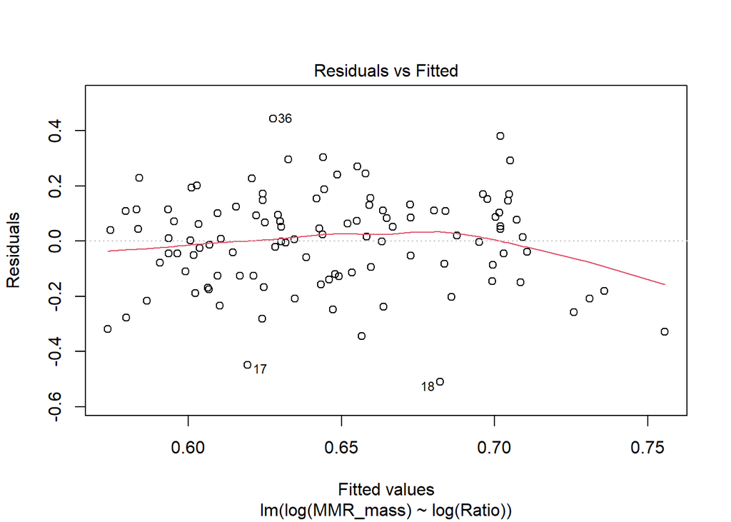

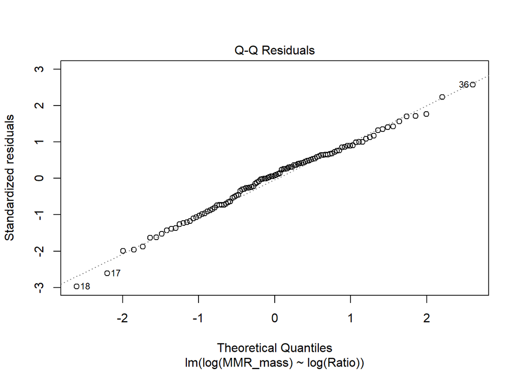

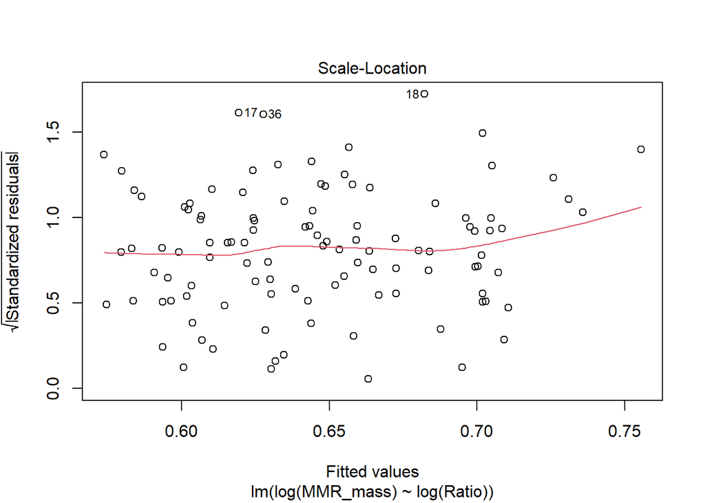

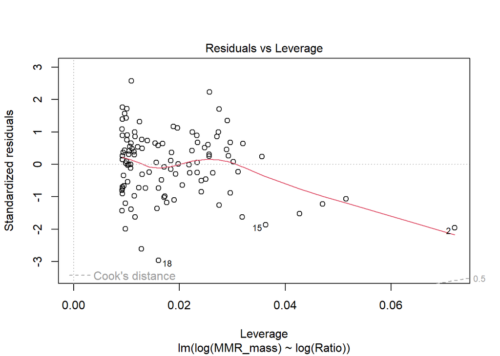

```r
lmod_MMR2 <- lm(log(MMR_mass) ~ log(Ratio), data = data_matstat_18)
plot(lmod_MMR2)
```

```r
summary(lmod_MMR2)
```

```
##
## Call:
## lm(formula = log(MMR_mass) ~ log(Ratio), data = data_matstat_18)
##
## Residuals:
##      Min       1Q   Median       3Q      Max
## -0.51037 -0.12502  0.01403  0.11157  0.44357
##
## Coefficients:
##             Estimate Std. Error t value Pr(>|t|)
## (Intercept)   2.0884     0.5706   3.660 0.000394 ***
## log(Ratio)   -0.3403     0.1345  -2.529 0.012892 *
## ---
## Signif. codes:  0 '***' 0.001 '**' 0.01 '*' 0.05 '.' 0.1 ' ' 1
##
## Residual standard error: 0.1731 on 107 degrees of freedom
## Multiple R-squared:  0.05641,    Adjusted R-squared:  0.04759
## F-statistic: 6.397 on 1 and 107 DF,  p-value: 0.01289
```